# 3. Logistic regression

For this exercise on logistic regression, we will be will be working on data from two questionnaires related to student performance. This data approaches student achievement in secondary education of two Portuguese schools. The data attributes include student grades, demographic, social and school related features) and it was collected by using school reports and questionnaires From this questionnaires, we are particularly interested in the data related to alcohol consumption.

## Reading the data

We will use a prepared data extracted from the previously mentioned data set. We modified it to obtain information relevant for our analysis on alcohol consumption. We will start reading the table, storing it into the variable “alc” and showing the names of the different columns.

```r
alc <- read.table("data/alc.csv", header = TRUE, sep = "\t")
colnames(alc)
```

```
##  [1] "school"     "sex"        "age"        "address"    "famsize"
##  [6] "Pstatus"    "Medu"       "Fedu"       "Mjob"       "Fjob"
## [11] "reason"     "nursery"    "internet"   "guardian"   "traveltime"
## [16] "studytime"  "failures"   "schoolsup"  "famsup"     "paid"
## [21] "activities" "higher"     "romantic"   "famrel"     "freetime"
## [26] "goout"      "Dalc"       "Walc"       "health"     "absences"
## [31] "G1"         "G2"         "G3"         "alc_use"    "high_use"
```

## Exploring the distributions

```r
library(tidyr)
library(dplyr)
```

```r
library(ggplot2)
library(GGally)
#We isolate the selected variables according to our hypothesis
pick <- c("high_use","sex","Medu","Fedu","absences")
alc_pick <- select(alc, one_of(pick))

#We create some plots with the variables
str(alc_pick)
```

```
## 'data.frame':    382 obs. of  5 variables:
##  $ high_use: logi  FALSE FALSE TRUE FALSE FALSE FALSE ...
##  $ sex     : Factor w/ 2 levels "F","M": 1 1 1 1 1 2 2 1 2 2 ...
##  $ Medu    : int  4 1 1 4 3 4 2 4 3 3 ...
##  $ Fedu    : int  4 1 1 2 3 3 2 4 2 4 ...
##  $ absences: int  5 3 8 1 2 8 0 4 0 0 ...
```

```r
gather(alc_pick) %>% glimpse()
```

```
## Observations: 1,910
## Variables: 2
## $ key   <chr> "high_use", "high_use", "high_use", "high_use", "high_use"…
## $ value <chr> "FALSE", "FALSE", "TRUE", "FALSE", "FALSE", "FALSE", "FALS…
```

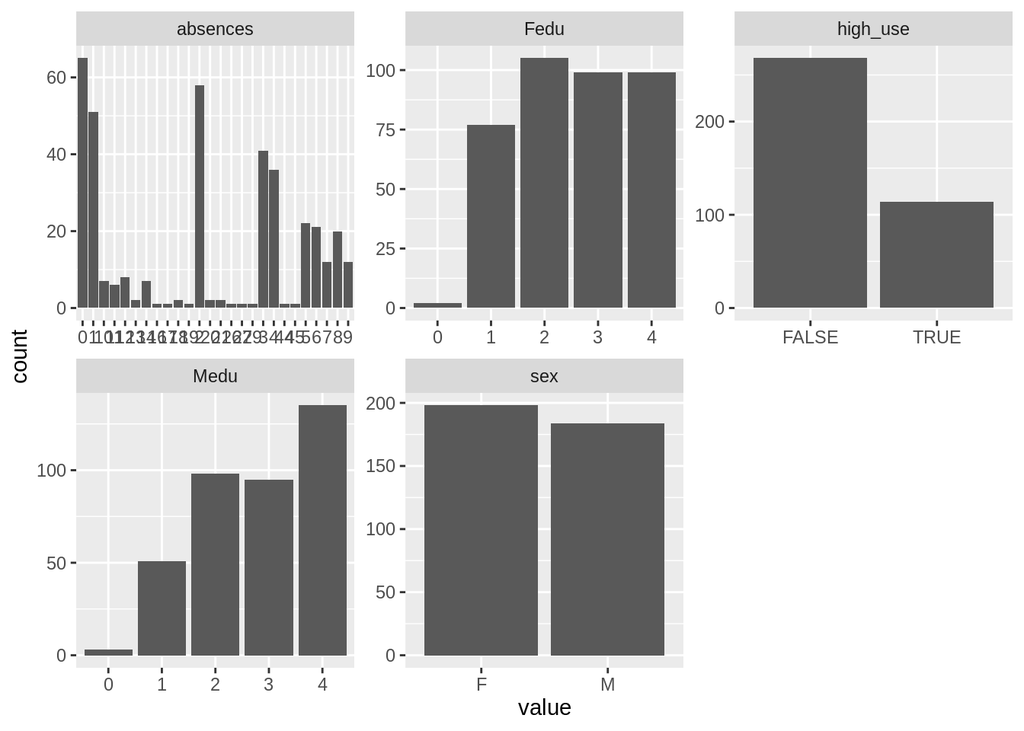

```r
gather(alc_pick) %>% ggplot(aes(value)) + facet_wrap("key", scales="free") + geom_bar()
```

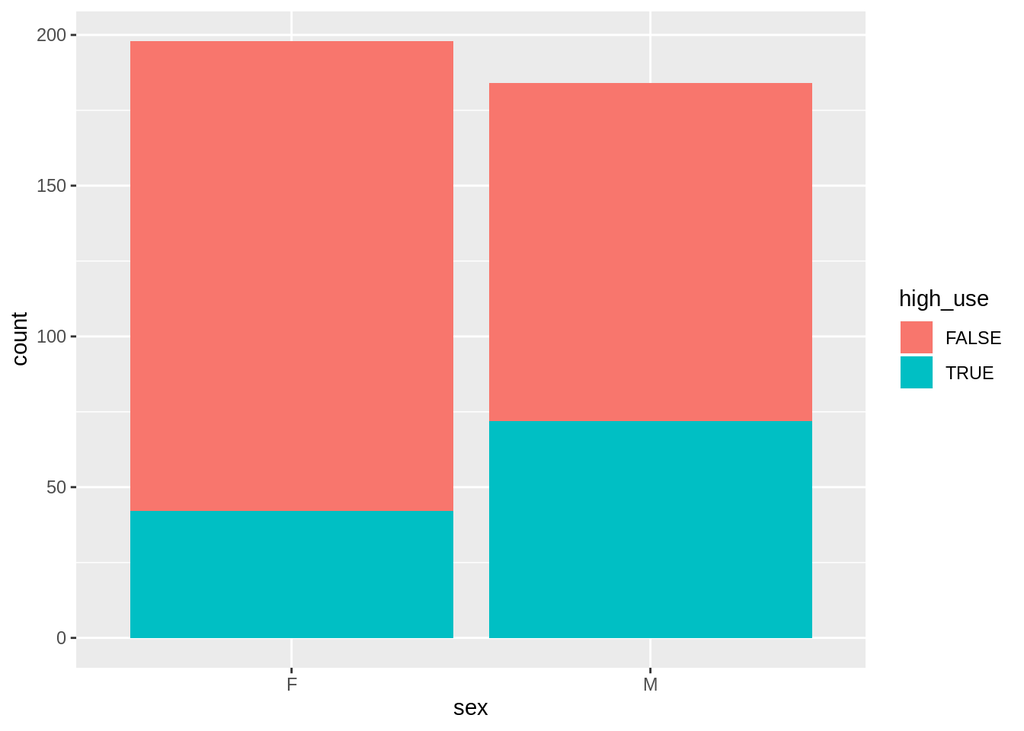

```r
p1 <- ggplot(alc_pick, aes(sex, fill=high_use))
p2 <- ggplot(alc_pick, aes(Medu, fill=high_use))
p3 <- ggplot(alc_pick, aes(Fedu, fill=high_use))
p4 <- ggplot(alc_pick, aes(x=high_use, y=absences))

p1 + geom_bar()
```

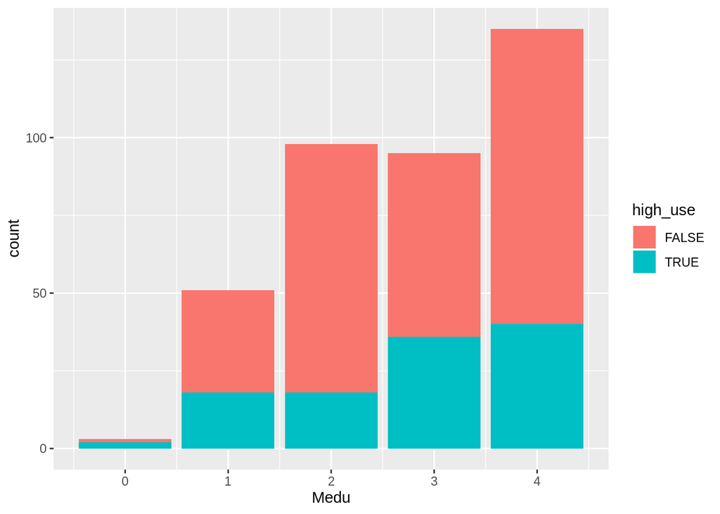

```r
p2 + geom_bar()
```

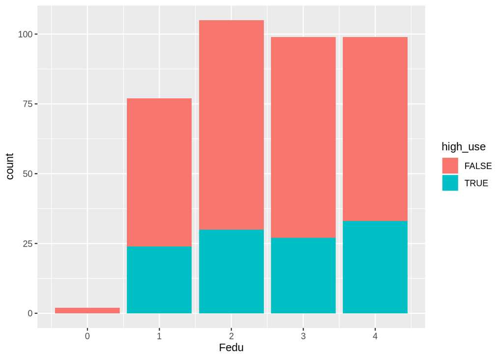

```r
p3 + geom_bar()
```

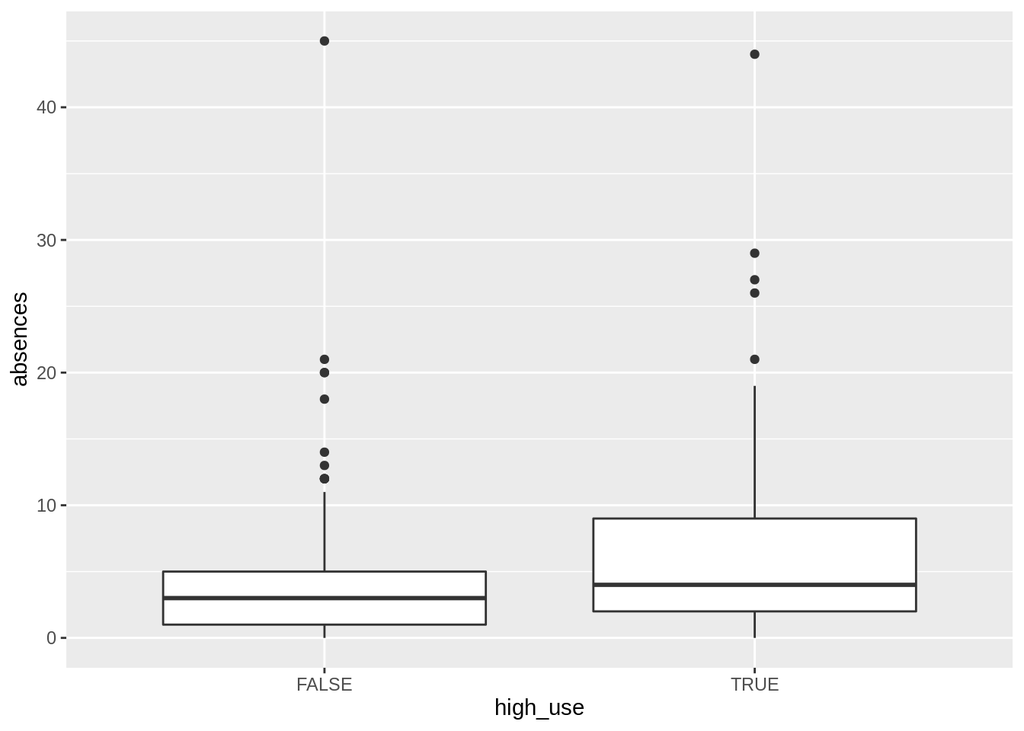

```r
p4 + geom_boxplot()
```

```r
table(alc_pick$high_use, alc_pick$sex)
```

```
##
##           F   M
##   FALSE 156 112
##   TRUE   42  72
```

```r
table(alc_pick$high_use, alc_pick$Medu)
```

```
##
##          0  1  2  3  4
##   FALSE  1 33 80 59 95
##   TRUE   2 18 18 36 40
```

```r
table(alc_pick$high_use, alc_pick$Fedu)
```

```
##
##          0  1  2  3  4
##   FALSE  2 53 75 72 66
##   TRUE   0 24 30 27 33
```

```r
table(alc_pick$high_use, alc_pick$absences)
```

```
##
##          0  1  2  3  4  5  6  7  8  9 10 11 12 13 14 16 17 18 19 20 21 26
##   FALSE 52 38 42 33 24 16 16  9 14  6  5  2  4  1  1  0  0  1  0  2  1  0
##   TRUE  13 13 16  8 12  6  5  3  6  6  2  4  4  1  6  1  1  1  1  0  1  1
##
##         27 29 44 45
##   FALSE  0  0  0  1
##   TRUE   1  1  1  0
```

For what we can see in this initial explorations, the sex variable seem to have a some relevance. Fedu (father’s education) shows similar results in both groups. However, Medu (mother’s education) and absences seem to have some indications of influence on alcohol consumption on young people.

## Logistic regression

```r
m <- glm(data=alc_pick, high_use ~ sex + Medu + Fedu + absences, family="binomial")
summary(m)
```

```
##
## Call:
## glm(formula = high_use ~ sex + Medu + Fedu + absences, family = "binomial",
##     data = alc_pick)
##
## Deviance Residuals:
##     Min       1Q   Median       3Q      Max
## -2.2692  -0.8616  -0.6186   1.0873   2.0814
##
## Coefficients:
##             Estimate Std. Error z value Pr(>|z|)
## (Intercept) -1.72690    0.37465  -4.609 4.04e-06 ***
## sexM         1.00307    0.24239   4.138 3.50e-05 ***
## Medu        -0.13932    0.14599  -0.954    0.340
## Fedu         0.10037    0.14230   0.705    0.481
## absences     0.09866    0.02327   4.240 2.23e-05 ***
## ---
## Signif. codes:  0 '***' 0.001 '**' 0.01 '*' 0.05 '.' 0.1 ' ' 1
##
## (Dispersion parameter for binomial family taken to be 1)
##
##     Null deviance: 465.68  on 381  degrees of freedom
## Residual deviance: 429.14  on 377  degrees of freedom
## AIC: 439.14
##
## Number of Fisher Scoring iterations: 4
```

```r
m2 <- glm(data=alc_pick, high_use ~ sex + absences, family="binomial")
summary(m2)
```

```
##
## Call:
## glm(formula = high_use ~ sex + absences, family = "binomial",
##     data = alc_pick)
##
## Deviance Residuals:
##     Min       1Q   Median       3Q      Max
## -2.2753  -0.8753  -0.6081   1.0921   1.9920
##
## Coefficients:
##             Estimate Std. Error z value Pr(>|z|)
## (Intercept) -1.83606    0.22251  -8.252  < 2e-16 ***
## sexM         0.97762    0.23982   4.076 4.57e-05 ***
## absences     0.09659    0.02306   4.189 2.80e-05 ***
## ---
## Signif. codes:  0 '***' 0.001 '**' 0.01 '*' 0.05 '.' 0.1 ' ' 1
##
## (Dispersion parameter for binomial family taken to be 1)
##
##     Null deviance: 465.68  on 381  degrees of freedom
## Residual deviance: 430.07  on 379  degrees of freedom
## AIC: 436.07
##
## Number of Fisher Scoring iterations: 4
```

```r
OR <- coef(m2) %>% exp
CI <- confint(m2) %>% exp
cbind(OR, CI)
```

```
##                   OR     2.5 %    97.5 %
## (Intercept) 0.159445 0.1012577 0.2427684
## sexM        2.658116 1.6710354 4.2863129
## absences    1.101409 1.0549317 1.1548057
```

```r
prob <- predict(m2, type="response")
alc_pick <- mutate (alc_pick, probs = prob)
alc_pick <- mutate(alc_pick, prediction = probs > .5)
table(high_use = alc_pick$high_use, prediction = alc_pick$prediction)
```

```
##         prediction
## high_use FALSE TRUE
##    FALSE   258   10
##    TRUE     88   26
```

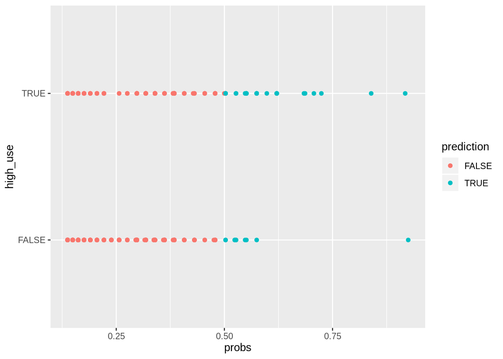

```r
# plot
ggplot(alc_pick, aes(x = probs, y = high_use, col = prediction)) + geom_point()
```